# Swire Project - Modeling

Chase Jensen

2023-03-10

## Introduction

The purpose of this document is to take a deeper dive into addressing the business problem of Swire Coca-cola, which again is to determine which potential customers will be the most successful. With a method in place to predict the success of customers, Swire will be able to select the best businesses to sell to.

### Models to Explore

In order to assist Swire in identifying successful businesses to work with, it is important to create an accurate and generalizable model to predict which customers will be successful. In terms of modeling we decided to explore the areas of customer segmentation using a clustering algorithm to determine patterns in existing customers and a form of regression to see what variables are significant in predicting customer success, namely Invoice Price, which for all intents and purposes can be viewed as revenue.

## Data Preparation and Feature Engineering

```r
library(readxlsb)
library(readxl)
library(tidyverse)
library(ggplot2)
library(ragtop)
library(ggmap)
library(corrplot)
```

```r
# Read in the data
custData <- read_excel("FSOP_Customer_Data_v2.0.xlsx")
salesData <- read_excel("FSOP_Sales_Data_v2.0.xlsx")
data = read.csv("combined_data.csv")


# Dropping some unneeded columns
data = data[, !names(data) %in% c("SALES_OFFICE_DESCRIPTION", "DELIVERY_PLANT_DESCRIPTION",
                                "COUNTY", "CUSTOMER_TRADE_CHANNEL_DESCRIPTION2",
                                "GEO_LONGITUDE", "GEO_LATITUDE", "ADDRESS_CITY",
                                "MARKET_DESCRIPTION")]

# Remove the data with invoice price <= 0 (These are most likely returns or damaged goods)

data = data[data$INVOICE_PRICE > 0,]


data$MIN_POSTING_DATE <- as.Date(data$MIN_POSTING_DATE)
data$MAX_POSTING_DATE <- as.Date(data$MAX_POSTING_DATE)
data$ON_BOARDING_DATE <- as.Date(data$ON_BOARDING_DATE)

chr_cols <- sapply(data, is.character)
data[chr_cols] <- lapply(data[chr_cols], as.factor)

str(data)
```

```
## 'data.frame':    694123 obs. of  22 variables:
##  $ CUSTOMER_NUMBER_BLINDED               : Factor w/ 35005 levels "C0001005009010198",..: 1 1 1 1 2 2 2 2 2 2 ...
##  $ ON_BOARDING_DATE                      : Date, format: "2016-08-04" "2016-08-04" ...
##  $ ADDRESS_ZIP_CODE                      : Factor w/ 22817 levels "57752","57763",..: 17970 17970 17970 17970 21578 21578 21578 21578 21578 21578 ...
##  $ CUSTOMER_ACTIVITY_CLUSTER_DESCRIPTION : Factor w/ 8 levels "At-Work","Eating & Drinking",..: 2 2 2 2 6 6 6 6 6 6 ...
##  $ CUSTOMER_TRADE_CHANNEL_DESCRIPTION    : Factor w/ 25 levels "All Other","Amusement",..: 16 16 16 16 3 3 3 3 3 3 ...
##  $ CUSTOMER_SUB_TRADE_CHANNEL_DESCRIPTION: Factor w/ 47 levels "Airline","Amusement/Theme Park",..: 23 23 23 23 19 19 19 19 19 19 ...
##  $ BUSINESS_TYPE_EXTENSION_DESCRIPTION   : Factor w/ 10 levels "Agency","Agency/Lcl Dr.Pepper",..: 5 5 5 5 5 5 5 5 5 5 ...
##  $ COLD_DRINK_CHANNEL_DESCRIPTION        : Factor w/ 9 levels "AT WORK","DESTINATION VENUE",..: 3 3 3 3 8 8 8 8 8 8 ...
##  $ PRODUCT_SOLD_BLINDED                  : Factor w/ 1320 levels "M000206740674",..: 1201 720 821 535 98 783 896 50 724 992 ...
##  $ BEV_CAT_DESC                          : Factor w/ 11 levels "COFFEE","CORE SPARKLING",..: 2 2 2 2 2 2 2 2 11 4 ...
##  $ CALORIE_CAT_DESC                      : Factor w/ 2 levels "LOW CALORIE",..: 2 2 2 1 2 2 2 2 2 2 ...
##  $ PACK_TYPE_DESC                        : Factor w/ 21 levels "Aluminum Bottle",..: 4 4 4 4 14 14 14 12 14 3 ...
##  $ PACK_SIZE_SALES_UNIT_DESCRIPTION      : Factor w/ 148 levels "0 ML 1-Ls","1 GALLON 1-Ls 2",..: 136 136 136 136 71 71 71 71 63 47 ...
##  $ PHYSICAL_VOLUME                       : num  12 33 9 18 15 3 4 17 15 30 ...
##  $ DISCOUNT                              : num  198 508 149 279 367 ...
##  $ INVOICE_PRICE                         : num  162 420 121 230 393 ...
##  $ DEAD_NET                              : num  162 420 121 230 353 ...
##  $ GROSS_PROFIT_DEAD_NET                 : num  71.5 195.3 26.8 113.2 201.4 ...
##  $ COGS                                  : num  71.2 176.2 80.2 98.1 118.1 ...
##  $ MIN_POSTING_DATE                      : Date, format: "2022-04-14" "2021-06-10" ...
##  $ MAX_POSTING_DATE                      : Date, format: "2022-11-25" "2022-11-25" ...
##  $ NUM_OF_TRANSACTIONS                   : int  9 13 9 14 64 24 32 67 48 30 ...
```

```r
# Calculate the total posting time (Time doing Business with Swire)
data$TOTAL_POSTING_TIME <- difftime(data$MAX_POSTING_DATE, data$MIN_POSTING_DATE, units = "days")
fivenum(data$TOTAL_POSTING_TIME)
```

```
## Time differences in days
## [1]   0  72 374 640 728
```

```r
mean(data$TOTAL_POSTING_TIME)
```

```
## Time difference of 360.9151 days
```

Below is a graph of the distribution of the new variable, Total Posting Time

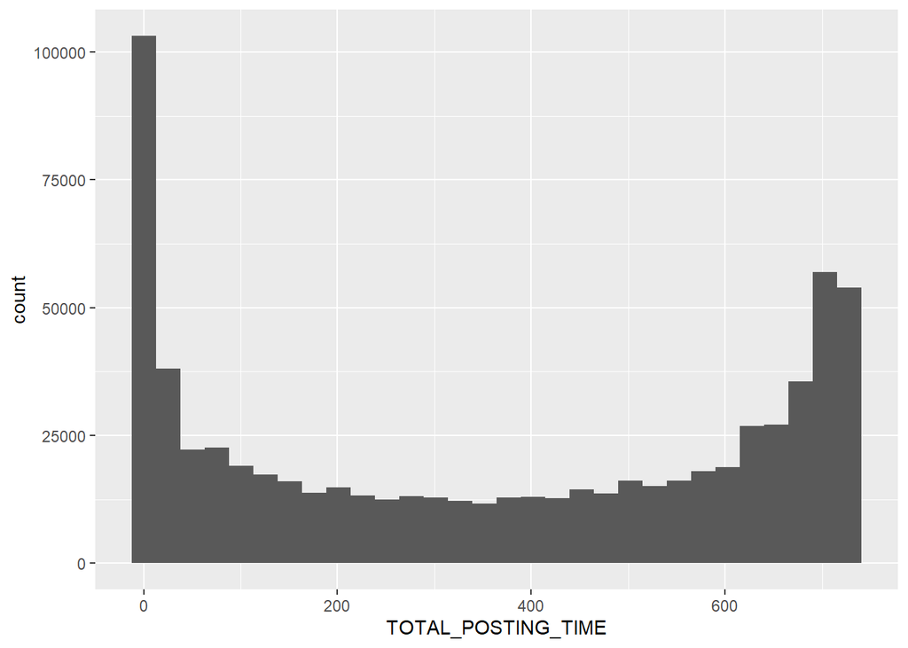

```r
ggplot(data = data, aes(x = TOTAL_POSTING_TIME)) + geom_histogram()
```

## Summary of Data Preparation and Engineering

Some key data transformations that were made include removing several variables that were redundant. For example, we do not need to know the customers city and zip code. This would lead to multicollinearity, which would negatively impact our model performance.

Other key preparation and engineering steps include factoring appropriate variables as well as converting dates to date format. We also created a new variable called Total Posting Time which is the difference between Max and Min Posting Time (The most recent and first transaction dates).

Additionally, we combined the sales and customer datasets to house all variables in one dataset for potential modeling. This would prove to be problematic, which we will discuss later.

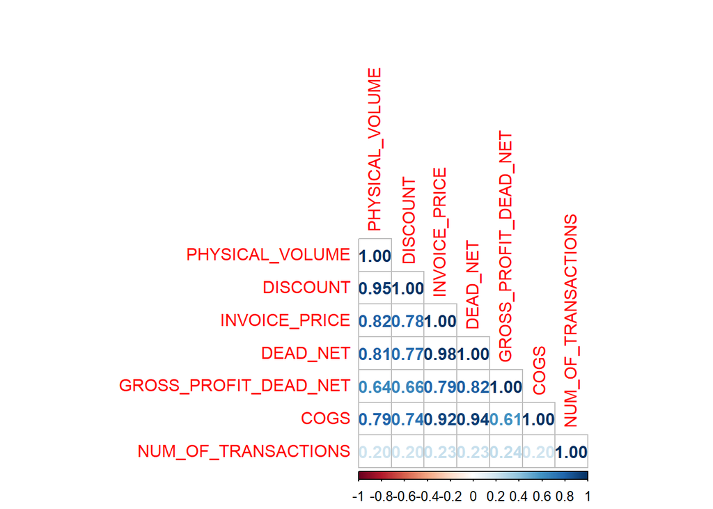

```r
data_num <- select_if(data, is.numeric)
d_corr <- cor(data_num)
corrplot(d_corr, type = "lower", method = "number")
```

```r
d_corr > .75
```

```
##                       PHYSICAL_VOLUME DISCOUNT INVOICE_PRICE DEAD_NET
## PHYSICAL_VOLUME                  TRUE     TRUE          TRUE     TRUE
## DISCOUNT                         TRUE     TRUE          TRUE     TRUE
## INVOICE_PRICE                    TRUE     TRUE          TRUE     TRUE
## DEAD_NET                         TRUE     TRUE          TRUE     TRUE
## GROSS_PROFIT_DEAD_NET           FALSE    FALSE          TRUE     TRUE
## COGS                             TRUE    FALSE          TRUE     TRUE
## NUM_OF_TRANSACTIONS             FALSE    FALSE         FALSE    FALSE
##                       GROSS_PROFIT_DEAD_NET  COGS NUM_OF_TRANSACTIONS
## PHYSICAL_VOLUME                       FALSE  TRUE               FALSE
## DISCOUNT                              FALSE FALSE               FALSE
## INVOICE_PRICE                          TRUE  TRUE               FALSE
## DEAD_NET                               TRUE  TRUE               FALSE
## GROSS_PROFIT_DEAD_NET                  TRUE FALSE               FALSE
## COGS                                  FALSE  TRUE               FALSE
## NUM_OF_TRANSACTIONS                   FALSE FALSE                TRUE
```

## Data Modeling

### Customer Clustering

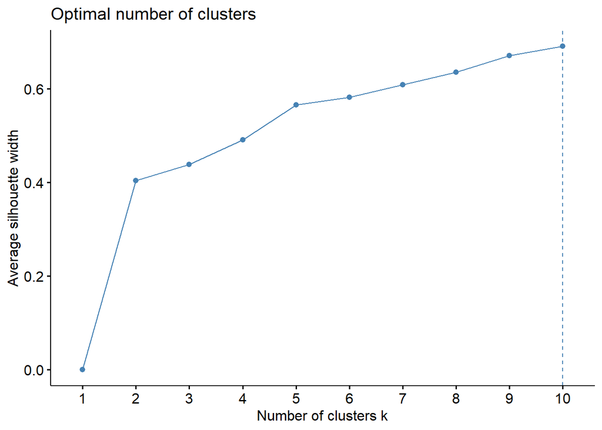

[output not shown]

```r
library(ggplot2)
library(factoextra)
library(cluster)
dist_matrix <- dist(custData, method = "euclidean")
hc <- hclust(dist_matrix, method = "ward.D2")

# Cut the tree at different heights to create different clustering solutions
cutree.res <- list()
for (i in 2:10) {
  cutree.res[[i]] <- cutree(hc, k = i)
}

# Compute the silhouette width for each clustering solution
sil.width <- sapply(cutree.res, function(x) {
  if (length(unique(x)) > 1) {
    cluster::silhouette(x, dist_matrix)
  } else {
    NA
  }
})

sil.width <- as.data.frame(sil.width)
# Plot the silhouette width for each clustering solution
fviz_nbclust(sil.width, FUNcluster = hcut)
```

As you can see from this output, it’s a mess.

### Regression

In terms of predictive modeling, we started with a simple linear regression as a baseline. Initially, we tried to create a model off of the entire joined dataset, but found that the output was too computationally expensive and large to be feasible. We turned our attention to a regression on only the sales data.

```r
str(salesData)
```

```
## tibble [831,858 × 15] (S3: tbl_df/tbl/data.frame)
##  $ CUSTOMER_NUMBER_BLINDED         : chr [1:831858] "C0051046109640797" "C0348074302380406" "C0277089703710223" "C0112072503650635" ...
##  $ PRODUCT_SOLD_BLINDED            : chr [1:831858] "M056203880974" "M042308250090" "M010605530774" "M050800200648" ...
##  $ BEV_CAT_DESC                    : chr [1:831858] "CORE SPARKLING" "CORE SPARKLING" "TEA" "ENERGY DRINKS" ...
##  $ CALORIE_CAT_DESC                : chr [1:831858] "REGULAR CALORIE" "LOW CALORIE" "LOW CALORIE" "REGULAR CALORIE" ...
##  $ PACK_TYPE_DESC                  : chr [1:831858] "Plastic Bottle - Contour" "Aluminum Can - Sleek" "Plastic Bottle - Other" "Aluminum Can" ...
##  $ PACK_SIZE_SALES_UNIT_DESCRIPTION: chr [1:831858] "20 OZ 1-Ls 24" "12 OZ 4-Pk 24" "18.5 OZ 1-Ls 12" "16 OZ 1-Ls 24" ...
##  $ PHYSICAL_VOLUME                 : num [1:831858] 88 58 108 15 195 ...
##  $ DISCOUNT                        : num [1:831858] 2246 1197 3429 307 3382 ...
##  $ INVOICE_PRICE                   : num [1:831858] 2506 1667 1755 593 2078 ...
##  $ DEAD_NET                        : num [1:831858] 1925 1469 1499 553 1813 ...
##  $ GROSS_PROFIT_DEAD_NET           : num [1:831858] 1112.7 316.2 403.2 77.9 661.2 ...
##  $ COGS                            : num [1:831858] 682 1186 1108 475 1417 ...
##  $ MIN_POSTING_DATE                : POSIXct[1:831858], format: "2021-01-12" "2021-02-02" ...
##  $ MAX_POSTING_DATE                : POSIXct[1:831858], format: "2022-12-30" "2022-12-30" ...
##  $ NUM_OF_TRANSACTIONS             : num [1:831858] 157 40 62 17 166 5 156 107 46 46 ...
```

```r
# Remove and restructure variables for LR
salesData$TOTAL_POSTING_TIME <- as.numeric(difftime(salesData$MAX_POSTING_DATE, salesData$MIN_POSTING_DATE, units = "days"))

salesData = salesData[, !names(salesData) %in% c("MAX_POSTING_DATE", "MIN_POSTING_DATE", "CUSTOMER_NUMBER_BLINDED")]

chr_cols_sales <- sapply(salesData, is.character)
salesData[chr_cols_sales] <- lapply(salesData[chr_cols_sales], as.factor)

salesData = salesData[salesData$INVOICE_PRICE > 0,]

# salesModel <- lm(INVOICE_PRICE ~., salesData)

# print(summary(salesModel))
# There may be too many factors here. Potentially reduce number thought
# Additional feature engineering.
```

When attempting to create a linear regression on the Sales Data, we run into memory issues. We could potentially avoid this by allocating more memory to RStudio, but for now, this is an obstacle that we will have to work around.

Additionally, there are are potential concerns that could arise from trying to model the Invoice Price (Profit). From above, we can see that there is a lot of evidence for multicollinearity, so using sales data to model, well, sales could be problematic.